# R Notebook

# I used the ‘response’ method to predict the probability of each outcome being a home run. I wanted a numerical result for each observation rather than a value being assigned by using ‘class’. I then bound the scores onto their respective sets that I predicted them from and changed the predictive column names to match each other that way I am then able to bind both the Train and Test sets back together to create one full data set. This will allow me to see all the predictions within one data set.

# I created a Receiver Operator Characteristic (ROC) Curve and calculated the AUC below to show how well the model performed. Judging by the findings, the model performed excellently as the AUC was tabulated at 0.9555 giving a 95% accuracy rating while the ROC had an almost perfect curve to the top left corner showing that the model’s supervised learning worked well.

```r
predTrainSet <- predict(newModel, TrainSet, type = "response")
predTestSet <- predict(newModel, TestSet, type = "response")
```

```r
TrainSet <- cbind(TrainSet, predTrainSet)
TestSet <- cbind(TestSet, predTestSet)
```

```r
names(TrainSet)[names(TrainSet) == "predTrainSet"] <- "HR_Pred"
names(TestSet)[names(TestSet) == "predTestSet"] <- "HR_Pred"
```

```r
HR_Full <- rbind(TrainSet, TestSet)
```

#ROC Curve

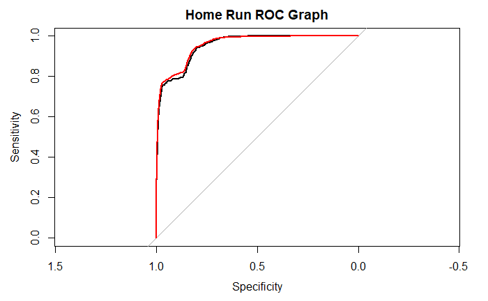

```r
roc_test <- roc(ifelse(TestSet$HOME_RUN_YES_OR_NO == "1", "1", "0"), as.numeric(TestSet$HR_Pred))
roc_train <- roc(ifelse(TrainSet$HOME_RUN_YES_OR_NO == "1", "1", "0"), as.numeric(TrainSet$HR_Pred))
plot(roc_test, col = "black", main = "Home Run ROC Graph")
lines(roc_train, col = "red")
```

```r
auc(HR_Full$HOME_RUN_YES_OR_NO, HR_Full$HR_Pred)
```

```
Area under the curve: 0.955
```

```r
HR_Full <- select(HR_Full, c(X, HOME_RUN_YES_OR_NO, HR_Pred, EXIT_VELOCITY, LAUNCH_ANGLE))
Least_Likely_HR <- filter(HR_Full, HOME_RUN_YES_OR_NO == 1)
Least_Likely_HR <- as.data.frame(Least_Likely_HR[order(Least_Likely_HR$HR_Pred),])
Least_Likely_HR
```

|  | X | HOME_RUN_YES_OR_NO | HR_Pred | EXIT_VELOCITY | LAUNCH_ANGLE |
| --- | --- | --- | --- | --- | --- |
| 1200 | 35373 | 1 | 0.01893891 | 97.31911 | 16.28764 |
| 1207 | 43882 | 1 | 0.04656688 | 96.04678 | 39.38582 |
| 1313 | 9431 | 1 | 0.04656845 | 95.92207 | 41.92793 |
| 366 | 54224 | 1 | 0.04694612 | 90.69135 | 38.75647 |
| 1062 | 30073 | 1 | 0.04732631 | 96.44474 | 38.61403 |
| 917 | 38770 | 1 | 0.04744230 | 95.43945 | 42.61938 |
| 2747 | 32007 | 1 | 0.04784632 | 90.41215 | 43.61887 |
| 643 | 54458 | 1 | 0.04823980 | 93.83334 | 37.12984 |
| 2983 | 54599 | 1 | 0.04828671 | 96.62179 | 41.88134 |
| 2382 | 44525 | 1 | 0.04850315 | 90.06332 | 32.83775 |

[output cut: 990 more lines]

[output not shown]

[output cut: 990 more lines]